# Решающие деревья. Random Forest.

Если набрать имя объекта дерева, R дает вывод, соответствующий каждой ветви дерева. R отображает критерий разделения (например, цена <92,5), количество наблюдений в этой ветви, отклонение, общее предсказание для ветки (Yes или No) и доли наблюдений в этой ветви, которые принимают значения «Да» и «Нет». Ветви, которые приводят к терминальным узлам, обозначаются звездочками.

```r
tree.carseats
```

```
## node), split, n, deviance, yval, (yprob)
##       * denotes terminal node
##
##   1) root 400 541.500 No ( 0.59000 0.41000 )
##     2) ShelveLoc: Bad,Medium 315 390.600 No ( 0.68889 0.31111 )
##       4) Price < 92.5 46  56.530 Yes ( 0.30435 0.69565 )
##         8) Income < 57 10  12.220 No ( 0.70000 0.30000 )
##          16) CompPrice < 110.5 5   0.000 No ( 1.00000 0.00000 ) *
##          17) CompPrice > 110.5 5   6.730 Yes ( 0.40000 0.60000 ) *
##         9) Income > 57 36  35.470 Yes ( 0.19444 0.80556 )
##          18) Population < 207.5 16  21.170 Yes ( 0.37500 0.62500 ) *
##          19) Population > 207.5 20   7.941 Yes ( 0.05000 0.95000 ) *
##       5) Price > 92.5 269 299.800 No ( 0.75465 0.24535 )
##        10) Advertising < 13.5 224 213.200 No ( 0.81696 0.18304 )
##          20) CompPrice < 124.5 96  44.890 No ( 0.93750 0.06250 )
##            40) Price < 106.5 38  33.150 No ( 0.84211 0.15789 )
##              80) Population < 177 12  16.300 No ( 0.58333 0.41667 )
##               160) Income < 60.5 6   0.000 No ( 1.00000 0.00000 ) *
##               161) Income > 60.5 6   5.407 Yes ( 0.16667 0.83333 ) *
##              81) Population > 177 26   8.477 No ( 0.96154 0.03846 ) *
##            41) Price > 106.5 58   0.000 No ( 1.00000 0.00000 ) *
##          21) CompPrice > 124.5 128 150.200 No ( 0.72656 0.27344 )
##            42) Price < 122.5 51  70.680 Yes ( 0.49020 0.50980 )
##              84) ShelveLoc: Bad 11   6.702 No ( 0.90909 0.09091 ) *
##              85) ShelveLoc: Medium 40  52.930 Yes ( 0.37500 0.62500 )
##               170) Price < 109.5 16   7.481 Yes ( 0.06250 0.93750 ) *
##               171) Price > 109.5 24  32.600 No ( 0.58333 0.41667 )
##                 342) Age < 49.5 13  16.050 Yes ( 0.30769 0.69231 ) *
##                 343) Age > 49.5 11   6.702 No ( 0.90909 0.09091 ) *
##            43) Price > 122.5 77  55.540 No ( 0.88312 0.11688 )
##              86) CompPrice < 147.5 58  17.400 No ( 0.96552 0.03448 ) *
##              87) CompPrice > 147.5 19  25.010 No ( 0.63158 0.36842 )
##               174) Price < 147 12  16.300 Yes ( 0.41667 0.58333 )
##                 348) CompPrice < 152.5 7   5.742 Yes ( 0.14286 0.85714 ) *
##                 349) CompPrice > 152.5 5   5.004 No ( 0.80000 0.20000 ) *
##               175) Price > 147 7   0.000 No ( 1.00000 0.00000 ) *
##        11) Advertising > 13.5 45  61.830 Yes ( 0.44444 0.55556 )
##          22) Age < 54.5 25  25.020 Yes ( 0.20000 0.80000 )
##            44) CompPrice < 130.5 14  18.250 Yes ( 0.35714 0.64286 )
##              88) Income < 100 9  12.370 No ( 0.55556 0.44444 ) *
##              89) Income > 100 5   0.000 Yes ( 0.00000 1.00000 ) *
##            45) CompPrice > 130.5 11   0.000 Yes ( 0.00000 1.00000 ) *
##          23) Age > 54.5 20  22.490 No ( 0.75000 0.25000 )
##            46) CompPrice < 122.5 10   0.000 No ( 1.00000 0.00000 ) *
##            47) CompPrice > 122.5 10  13.860 No ( 0.50000 0.50000 )
##              94) Price < 125 5   0.000 Yes ( 0.00000 1.00000 ) *
##              95) Price > 125 5   0.000 No ( 1.00000 0.00000 ) *
##     3) ShelveLoc: Good 85  90.330 Yes ( 0.22353 0.77647 )
##       6) Price < 135 68  49.260 Yes ( 0.11765 0.88235 )
##        12) US: No 17  22.070 Yes ( 0.35294 0.64706 )
##          24) Price < 109 8   0.000 Yes ( 0.00000 1.00000 ) *
##          25) Price > 109 9  11.460 No ( 0.66667 0.33333 ) *
##        13) US: Yes 51  16.880 Yes ( 0.03922 0.96078 ) *
##       7) Price > 135 17  22.070 No ( 0.64706 0.35294 )
##        14) Income < 46 6   0.000 No ( 1.00000 0.00000 ) *
##        15) Income > 46 11  15.160 Yes ( 0.45455 0.54545 ) *
```

Чтобы правильно оценить эффективность дерева классификации этих данных, необходимо оценить тестовую ошибку, а не просто вычислять ошибку обучения.

Разделим наблюдения на тренировочный набор и тестовый набор, построим дерево с использованием набора для обучения и оценим его производительность по тестовым данным.

Для этой цели можно использовать функцию $\mathrm{predict()}$. В случае дерева классификации аргумент $\mathrm{type ="class"}$ инструктирует R возвращать фактическое предсказание класса.

```r
set.seed(2)
train<-sample(1: nrow(Carseats), 200)
Carseats.test<-Carseats[-train, ]
High.test<-High[-train ]

tree.carseats<-tree(High~.-Sales, Carseats ,subset=train)
tree.pred<-predict(tree.carseats, Carseats.test, type ="class") #Возвращает вектор прогнозируемых ответов
table(tree.pred, High.test)
```

```
##          High.test
## tree.pred No Yes
##       No  86  27
##       Yes 30  57
```

```r
mean(High.test == tree.pred)
```

```
## [1] 0.715
```

Этот подход приводит к правильным прогнозам примерно для 71.5% мест в наборе тестовых данных.

Посмотрим, приведет ли обрезка дерева к улучшению результатов. Функция $\mathrm{cv.tree()}$ выполняет кросс-валидацию, чтобы определить оптимальный уровень сложности дерева; Cost complexity pruning (слабая обрезка) используется для выбора последовательности деревьев для рассмотрения.

Используем аргумент $\mathrm{FUN = prune.misclass}$, чтобы указать, что хотим число ошибочных классификаций, чтобы управлять процессом обрезки, а не значение по умолчанию для функции $\mathrm{cv.tree()}$, которое является отклонением.

Функция $\mathrm{cv.tree ()}$ сообщает количество терминальных узлов каждого рассматриваемого дерева ($\mathrm{size}$), а также сумму ошибочных классификаций в каждом листе ($\mathrm{dev}$) и значение используемого параметра сложности $\alpha$- это компромисс между размером дерева и его соответствию данным ($\mathrm{k}$).

```r
set.seed(3)
cv.carseats<-cv.tree(tree.carseats, FUN=prune.misclass)
names(cv.carseats)
```

```
## [1] "size"   "dev"    "k"      "method"
```

```r
cv.carseats
```

```
## $size
## [1] 19 17 14 13  9  7  3  2  1
##
## $dev
## [1] 55 55 53 52 50 56 69 65 80
##
## $k
## [1]       -Inf  0.0000000  0.6666667  1.0000000  1.7500000  2.0000000
## [7]  4.2500000  5.0000000 23.0000000
##
## $method
## [1] "misclass"
##
## attr(,"class")
## [1] "prune"         "tree.sequence"
```

Дерево с 9 терминальными узлами приводит к самой низкой частоте ошибок перекрестной проверки (50 ошибок). Определяем частоту ошибок как функцию от размера $\mathrm{size}$ и параметра сложности $\mathrm{k}$.

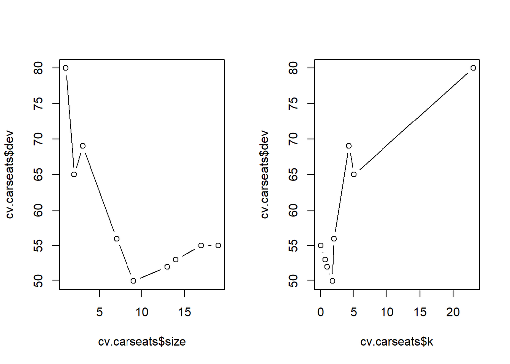

```r
par(mfrow =c(1,2)) #для установки графических параметров
plot(cv.carseats$size, cv.carseats$dev, type="b")
plot(cv.carseats$k, cv.carseats$dev, type="b")
```

Теперь применим функцию $\mathrm{prune.misclass()}$, чтобы обрезать дерево и получить дерево с девятью узлами.

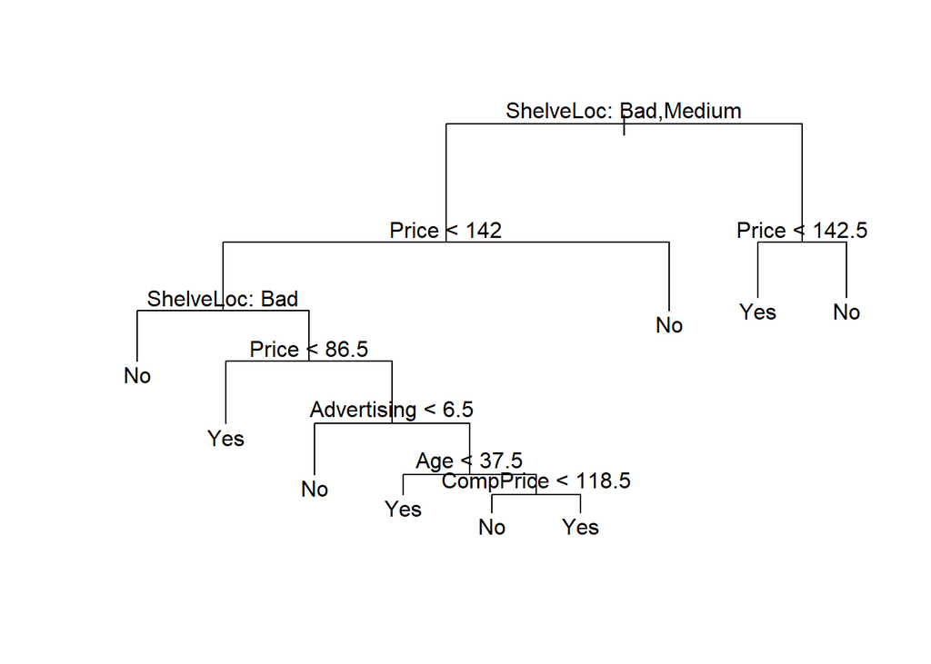

```r
prune.carseats<-prune.misclass(tree.carseats, best =9)
plot(prune.carseats)
text(prune.carseats, pretty =0)
```

Насколько хорошо это обрезанное дерево работает на тестовых данных? Применим функцию $\mathrm{predict()}$.

```r
tree.pred<-predict(prune.carseats, Carseats.test, type="class")
table(tree.pred, High.test)
```

```
##          High.test
## tree.pred No Yes
##       No  94  24
##       Yes 22  60
```

```r
mean(High.test == tree.pred)
```

```
## [1] 0.77
```

Теперь 77% тестовых наблюдений правильно классифицированы, поэтому процесс обрезки дает не только более интерпретируемое дерево, но также улучшает точность классификации. Если увеличить значение $\mathrm{best}$, получим более крупное обрезанное дерево с более низкой степенью точности классификации:

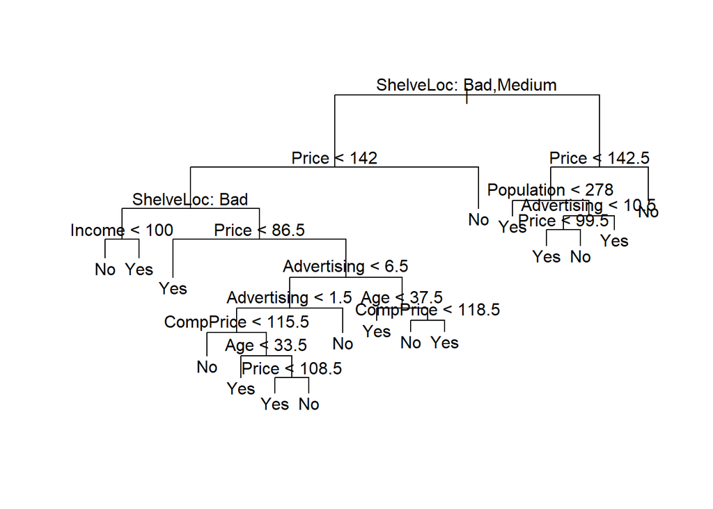

```r
prune.carseats<-prune.misclass(tree.carseats, best =15)
plot(prune.carseats)
text(prune.carseats, pretty =0)
```

```r
tree.pred<-predict(prune.carseats, Carseats.test, type="class")
table(tree.pred, High.test)
```

```
##          High.test
## tree.pred No Yes
##       No  86  22
##       Yes 30  62
```

```r
mean(High.test == tree.pred)
```

```
## [1] 0.74
```

### Bagging and Random Forests for classification

Применим bagging и random forests к данным Carseats, используя пакет $\mathrm{randomForest}$.

Напоминание: bagging- это просто частный случай случайного леса с m = p, где m- используемое число признаков, а p- общее число предикторов. Поэтому функция $\mathrm{randomForest()}$ может использоваться для выполнения как random forests, так и bagging.

Рассмотрим два варианта подсчета test error:

1)Построение деревьев на основе тренировочной выборки и подсчет ошибки на тестовой выборке.

2)Для оценки test error в методах bagging и случайный лес можно использовать OOB оценку, тогда нет необходимости делить выборку на тренировочную и тестовую.

##### Вариант 1)

Выполним bagging слудующим образом:

```r
library(randomForest)
set.seed(1)
bag.carseats<-randomForest(High~.-Sales, data=Carseats, subset =train, mtry=10, importance =TRUE)

bag.carseats
```

```
##
## Call:
##  randomForest(formula = High ~ . - Sales, data = Carseats, mtry = 10,      importance = TRUE, subset = train)
##                Type of random forest: classification
##                      Number of trees: 500
## No. of variables tried at each split: 10
##
##         OOB estimate of  error rate: 20.5%
## Confusion matrix:
##      No Yes class.error
## No  108  12      0.1000
## Yes  29  51      0.3625
```

Насколько хорошо эта bagging модель работает на тестовом наборе?

```r
yhat.bag<-predict(bag.carseats, newdata=Carseats [-train ,])
table(pred =yhat.bag, true =High.test)
```

```
##      true
## pred  No Yes
##   No  97  17
##   Yes 19  67
```

```r
mean(High.test == yhat.bag)
```

```
## [1] 0.82
```

Теперь 82% тестовых наблюдений правильно классифицированы. Следовательно, bagging улучшает точность прогнозирования по сравнению с tree model.

Можно изменить количество деревьев, выращенных методом $\mathrm{randomForest ()}$, используя аргумент $\mathrm{ntree}$. Количество деревьев не является критическим параметром при использовании бэггинга: очень большое значение не приведет к переобучению. На практике обычно используется значение $\mathrm{ntree}$ достаточно большое для стабилизации ошибки (по умолчанию, $\mathrm{ntree}$=500).

Выращивание случайного леса происходит точно так же, за исключением того, что используется меньшее значение аргумента mtry.

По умолчанию $\mathrm{randomforest ()}$ использует $\frac{p}{3}$ переменных при построении случайного леса деревьев регрессии и $\sqrt{p}$ переменных при построении случайного леса деревьев классификации.

Выполним random forest следующим образом:

```r
set.seed(1)
rf.carseats<-randomForest(High~.-Sales, data=Carseats, subset=train, mtry=6, importance =TRUE)

yhat.rf<-predict(rf.carseats, newdata=Carseats[-train ,])
table(pred =yhat.rf, true =High.test)
```

```
##      true
## pred  No Yes
##   No  98  18
##   Yes 18  66
```

```r
mean(High.test == yhat.rf)
```

```
## [1] 0.82
```

Уровень ошибочной классификации не изменился по сравнению с bagging. 82% тестовых наблюдений правильно классифицированы.

##### Вариант 2)

Выполним bagging следующим образом:

```r
library(randomForest)
set.seed(1)
bag.carseats<-randomForest(High~.-Sales, data=Carseats, mtry=10, importance =TRUE)

bag.carseats
```

```
##
## Call:
##  randomForest(formula = High ~ . - Sales, data = Carseats, mtry = 10,      importance = TRUE)
##                Type of random forest: classification
##                      Number of trees: 500
## No. of variables tried at each split: 10
##
##         OOB estimate of  error rate: 19.5%
## Confusion matrix:
##      No Yes class.error
## No  208  28   0.1186441
## Yes  50 114   0.3048780
```

```r
#OOB estimate of  error rate (оценка тестовой ошибки)
(28+50)/400
```

```
## [1] 0.195
```

Вышеуказанный коэффициент ошибок классификации вычисляется с использованием оценки Out-of-Bag Error: $\frac{2}{3}$ данных используются для обучения, а остальные $\frac{1}{3}$ (OOB) используются для проверки деревьев.

Теперь 80.5% наблюдений правильно классифицированы. Следовательно, bagging улучшает точность прогнозирования по сравнению с tree model.

Выполним random forest следующим образом:

```r
set.seed(1)
rf.carseats<-randomForest(High~.-Sales, data=Carseats, mtry=3, importance =TRUE)

rf.carseats
```

```
##
## Call:
##  randomForest(formula = High ~ . - Sales, data = Carseats, mtry = 3,      importance = TRUE)
##                Type of random forest: classification
##                      Number of trees: 500
## No. of variables tried at each split: 3
##
##         OOB estimate of  error rate: 18.75%
## Confusion matrix:
##      No Yes class.error
## No  210  26   0.1101695
## Yes  49 115   0.2987805
```

```r
#OOB estimate of  error rate (оценка тестовой ошибки)
(26+49)/400
```

```
## [1] 0.1875
```

Оценим важность каждой переменной:

```r
importance(rf.carseats)
```

```
##                     No        Yes MeanDecreaseAccuracy MeanDecreaseGini
## CompPrice   10.1784027  8.3744034           13.5170222        21.643596
## Income       4.6038121  3.4894109            5.6598325        19.882962
## Advertising 10.5623425 17.5361345           18.4713079        23.542139
## Population  -3.2349095 -2.6119313           -4.1291028        16.083797
## Price       30.3788407 27.2476237           37.4170757        43.532037
## ShelveLoc   33.6145976 33.3068045           41.5126710        30.484572
## Age          9.3617779  8.0247168           11.9332879        22.565008
## Education   -0.9499837  0.3203199           -0.4993204         9.809238
## Urban       -0.7949523 -0.6293717           -0.9340235         2.046674
## US           2.5533006  4.9963065            5.8554309         3.339995
```

Два измерения важности переменной:

1. MeanDecreaseAccuracy- cреднее снижение точности (коэффициент ошибок для классификации).
2. MeanDecreaseGini- cреднее падение индекса Джини. При каждом ветвлении на дереве падает индекс Джини. Для каждой переменной можно посчитать суммарное падение индекса Джини, вызванное ветвлениями на базе этой переменной. Посчитав среднее падение Джини по всем деревьям получим меру важности.

Графики этих мер важности:

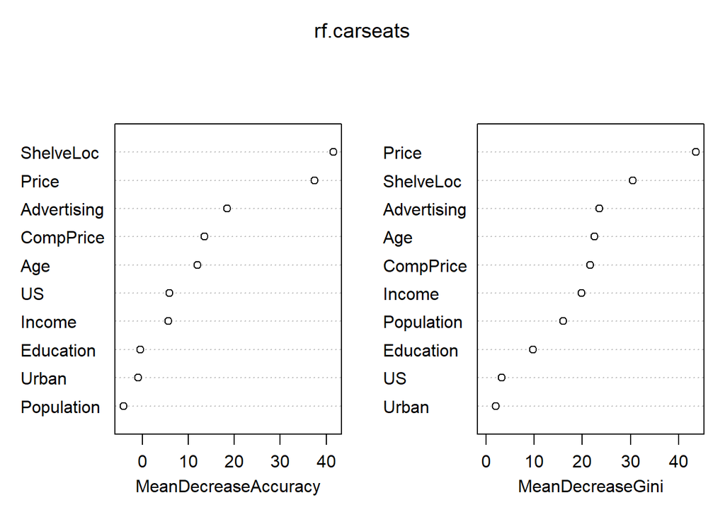

```r
varImpPlot(rf.carseats)
```

Результаты показывают, что на всех деревьях, рассматриваемых в случайном лесу, место расположения магазина (ShelveLoc) и стоимость детского автомобильного кресла (Price) являются двумя наиболее важными переменными.

### Regression Trees

Рассмотрим набор данных Boston: стоимость жилья в пригородах Бостона.

```r
Boston[1:10,]
```

```
##       crim   zn indus chas   nox    rm   age    dis rad tax ptratio  black
## 1  0.00632 18.0  2.31    0 0.538 6.575  65.2 4.0900   1 296    15.3 396.90
## 2  0.02731  0.0  7.07    0 0.469 6.421  78.9 4.9671   2 242    17.8 396.90
## 3  0.02729  0.0  7.07    0 0.469 7.185  61.1 4.9671   2 242    17.8 392.83
## 4  0.03237  0.0  2.18    0 0.458 6.998  45.8 6.0622   3 222    18.7 394.63
## 5  0.06905  0.0  2.18    0 0.458 7.147  54.2 6.0622   3 222    18.7 396.90
## 6  0.02985  0.0  2.18    0 0.458 6.430  58.7 6.0622   3 222    18.7 394.12
## 7  0.08829 12.5  7.87    0 0.524 6.012  66.6 5.5605   5 311    15.2 395.60
## 8  0.14455 12.5  7.87    0 0.524 6.172  96.1 5.9505   5 311    15.2 396.90
## 9  0.21124 12.5  7.87    0 0.524 5.631 100.0 6.0821   5 311    15.2 386.63
## 10 0.17004 12.5  7.87    0 0.524 6.004  85.9 6.5921   5 311    15.2 386.71
##    lstat medv
## 1   4.98 24.0
## 2   9.14 21.6
## 3   4.03 34.7
## 4   2.94 33.4
## 5   5.33 36.2
## 6   5.21 28.7
## 7  12.43 22.9
## 8  19.15 27.1
## 9  29.93 16.5
## 10 17.10 18.9
```

#### Данные

##### 506 наблюдений и 14 переменных:

Сrim- уровень преступности в городе на душу населения,

Zn- доля жилой земли, разделенной на участки более 25 000 кв. футов,

Indus- доля земли в городе, не подлежащая продаже,

Chas- фиктивная переменная Charles River: 1- если река пересекает земельный участок, 0- в противном случае,

Nox- концентрация оксидов азота (частей на 10 миллионов),

Rm- среднее количество комнат жилья,

Age- доля участвов, заселенных до 1940 года,

Dis- взвешенное среднее расстояний до пяти центров занятости в Бостоне,

Rad- индекс доступности радиальных магистралей,

Tax- налог на имущество (в 10 000 долларов),

Ptratio- соотношение учеников и учителей по городу,

Black- $1000*(B_k-0.63)^2$, где $B_k$- доля чернокожих в городе,

Lstat- низкий статус населения (в процентах),

Medv- медианная стоимость домов, занятых владельцами (в 1000 долларов).

Создадим обучающий набор и построим дерево с использованием набора для обучения. Используем функцию $\mathrm{tree()}$ для построения дерева регрессии.

```r
set.seed(1)
train<-sample(1: nrow(Boston ), nrow(Boston )/2)

#Выращивается дерево путем двоичного разбиения
tree.boston<-tree(medv~.,Boston, subset =train)
summary(tree.boston )
```

```
##
## Regression tree:
## tree(formula = medv ~ ., data = Boston, subset = train)
## Variables actually used in tree construction:
## [1] "lstat" "rm"    "dis"
## Number of terminal nodes:  8
## Residual mean deviance:  12.65 = 3099 / 245
## Distribution of residuals:
##      Min.   1st Qu.    Median      Mean   3rd Qu.      Max.
## -14.10000  -2.04200  -0.05357   0.00000   1.96000  12.60000
```

```r
#total residual deviance
sum(sapply(resid(tree.boston),function(x)(x-mean(resid(tree.boston)))^2))
```

```
## [1] 3098.61
```

Обратите внимание, что вывод $\mathrm{summary ()}$ указывает, что для построения дерева использовались только три из переменных. В выводе отображается количество терминальныъ узлов, остаточное среднее отклонение, общее остаточное отклонение- это просто сумма квадратов ошибок для дерева в контексте дерева регрессии. Построим дерево:

Используем функцию $\mathrm{plot()}$ для отображения древовидной структуры и функцию $\mathrm{text()}$ для отображения меток узлов.

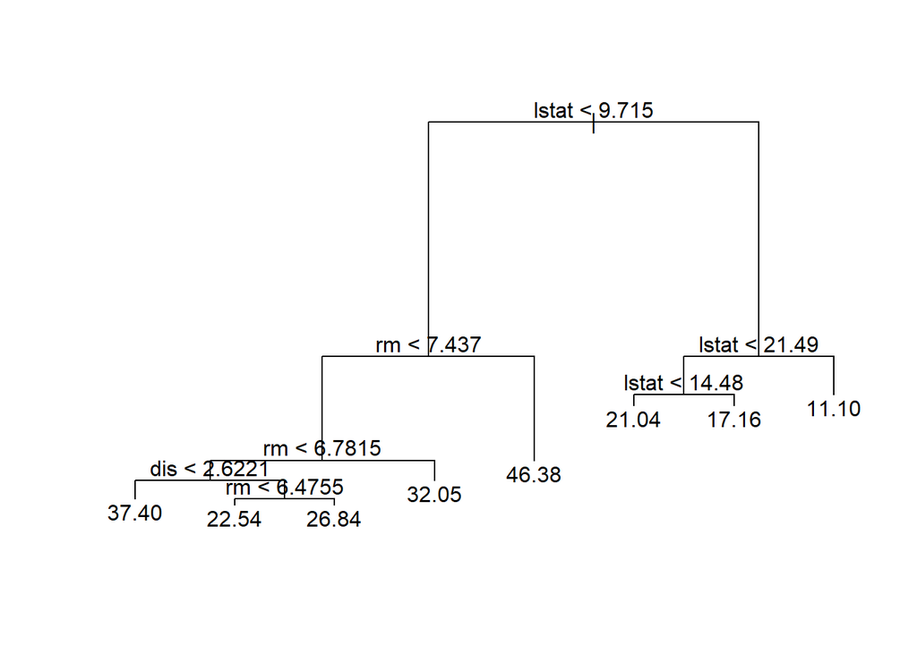

```r
plot(tree.boston)
text(tree.boston)
```

Дерево указывает, что маленькие значения lstat (процент лиц с низким социально-экономическим статусом) соответствуют более дорогим домам. Дерево предсказывает, что стоимость дома в размере 46 400 долларов соответствует более крупным домам в пригородах, где жители имеют высокий социально-экономический статус (rm $\ge$ 7.437 и lstat <9.715).

Теперь используем функцию $\mathrm{cv.tree ()}$, чтобы увидеть, улучшит ли дерево pruning. Функция $\mathrm{cv.tree()}$ выполняет кросс-валидацию, чтобы определить оптимальный уровень сложности дерева; Cost complexity pruning (слабая обрезка) используется для выбора последовательности деревьев для рассмотрения.

Функция $\mathrm{cv.tree ()}$ сообщает количество терминальных узлов каждого рассматриваемого дерева ($\mathrm{size}$), а также отклонение ($\mathrm{dev}$) и значение используемого параметра сложности $\alpha$- это компромисс между размером дерева и его соответствию данным ($\mathrm{k}$). Для регресии $\mathrm{dev = RSS}$.

```r
cv.boston<-cv.tree(tree.boston)

cv.boston
```

```
## $size
## [1] 8 7 6 5 4 3 2 1
##
## $dev
## [1]  5226.322  5228.360  6462.626  6692.615  6397.438  7529.846 11958.691
## [8] 21118.139
##
## $k
## [1]      -Inf  255.6581  451.9272  768.5087  818.8885 1559.1264 4276.5803
## [8] 9665.3582
##
## $method
## [1] "deviance"
##
## attr(,"class")
## [1] "prune"         "tree.sequence"
```

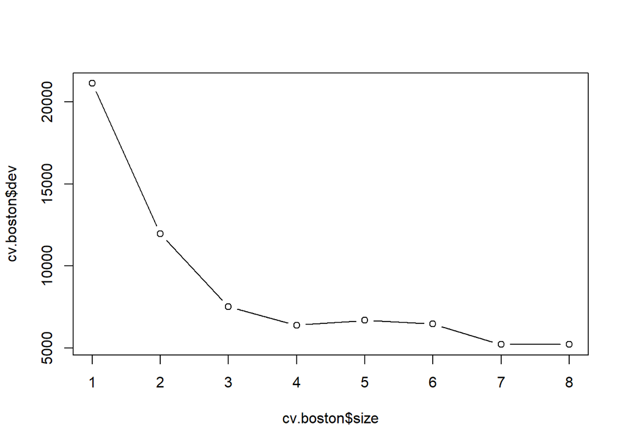

```r
plot(cv.boston$size, cv.boston$dev, type='b')
```

Мы могли бы сделать обрезку дерева, используя функцию $\mathrm{prune.tree ()}$, но по графику видно, что дерево с 8 терминальными узлами приводит к самой низкой сумме квадратов ошибок для дерева. Следовательно, обрезка не требуется.

Используем unpruned дерево, чтобы сделать прогнозы на тестовом наборе. Для этой цели можно использовать функцию $\mathrm{predict()}$:

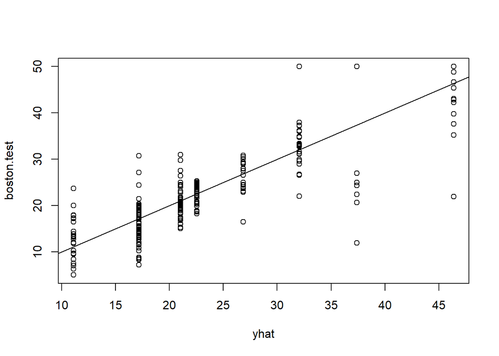

```r
yhat<-predict(tree.boston, newdata=Boston[-train ,])
boston.test<-Boston [-train ,"medv"]

#График наблюдаемых значений (по оси x) и прогнозируемых значений (ось y)
plot(yhat, boston.test)

# Добавим диагональную линию
abline(0,1)
```

```r
# Вычисление MSE тестового набора
mean((yhat-boston.test)^2)
```

```
## [1] 25.04559
```

MSE тестового набора, связанная с деревом регрессии, равна 25.05. Таким образом, квадратный корень из MSE составляет около 5.005, что указывает на то, что эта модель приводит к предсказаниям тестового набора, которые отклоняются на $ 5.005 от истинной медианной стоимости домов в пригороде (medv).

### Bagging and Random Forests for regression

Применим bagging и random forests к данным Бостона, используя пакет $\mathrm{randomForest}$.

Рассмотрим два варианта подсчета test error:

1)Построение деревьев на основе тренировочной выборки и подсчет ошибки на тестовой выборке.

2)Для оценки test error в методах bagging и случайный лес можно использовать OOB оценку, тогда нет необходимости делить выборку на тренировочную и тестовую.

##### Вариант 1)

Выполним bagging слудующим образом:

```r
library(randomForest)
set.seed(1)
bag.boston<-randomForest(medv~., data=Boston, subset =train, mtry=13, importance =TRUE)

bag.boston
```

```
##
## Call:
##  randomForest(formula = medv ~ ., data = Boston, mtry = 13, importance = TRUE,      subset = train)
##                Type of random forest: regression
##                      Number of trees: 500
## No. of variables tried at each split: 13
##
##           Mean of squared residuals: 11.02509
##                     % Var explained: 86.65
```

Аргумент $\mathrm{mtry = 13}$ указывает на то, что для каждого разбиения дерева следует учитывать все 13 предикторов.

Насколько хорошо эта bagging модель работает на тестовом наборе?

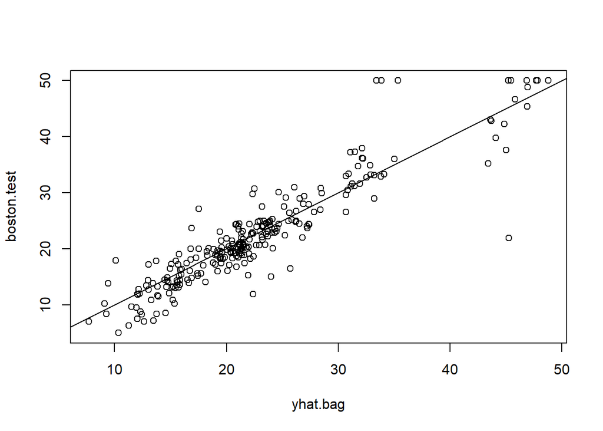

```r
yhat.bag<-predict(bag.boston, newdata=Boston [-train ,])

#График наблюдаемых значений (по оси x) и прогнозируемых значений (ось y)
plot(yhat.bag, boston.test)
abline(0,1)
```

```r
mean((yhat.bag-boston.test)^2)
```

```
## [1] 13.47349
```

MSE тестового набора, связанная с bagged regression tree, составляет 13.47, что почти вдвое меньше, чем полученное с использованием оптимального обрезанного дерева.

Можно изменить количество деревьев, выращенных методом $\mathrm{randomForest ()}$, используя аргумент $\mathrm{ntree}$. Количество деревьев не является критическим параметром при использовании бэггинга: очень большое значение не приведет к переобучению. На практике обычно используется значение $\mathrm{ntree}$ достаточно большое для стабилизации ошибки (по умолчанию, $\mathrm{ntree}$=500).

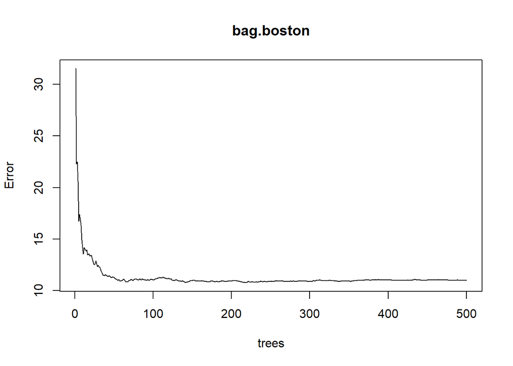

```r
plot(bag.boston)
```

Выполним random forest следующим образом:

```r
set.seed(1)
rf.boston<-randomForest(medv~., data=Boston, subset=train, mtry=6, importance =TRUE)
yhat.rf<-predict(rf.boston, newdata=Boston[-train ,])

mean((yhat.rf -boston.test)^2)
```

```
## [1] 11.48022
```

MSE тестового набора составляет 11.48. В этом случае случайные леса дали улучшение по сравнению с bagging.

##### Вариант 2)

Выполним bagging слудующим образом:

```r
library(randomForest)
set.seed(1)
bag.boston<-randomForest(medv~., data=Boston, mtry=13, importance =TRUE)

bag.boston
```

```
##
## Call:
##  randomForest(formula = medv ~ ., data = Boston, mtry = 13, importance = TRUE)
##                Type of random forest: regression
##                      Number of trees: 500
## No. of variables tried at each split: 13
##
##           Mean of squared residuals: 10.38495
##                     % Var explained: 87.7
```

Вышеуказанные MSE вычисляется с использованием оценки Out-of-Bag Error. $\frac{2}{3}$ данных используются для обучения, а остальные $\frac{1}{3}$ (OOB) используются для проверки деревьев.

Аргумент $\mathrm{mtry = 13}$ указывает на то, что для каждого разбиения дерева следует учитывать все 13 предикторов.

OOB MSE, связанная с bagged regression tree, составляет 10.38, что гораздо меньше, чем полученное с использованием tree model.

Выполним random forest следующим образом:

```r
set.seed(1)
rf.boston<-randomForest(medv~., data=Boston, mtry=6, importance =TRUE)

rf.boston
```

```
##
## Call:
##  randomForest(formula = medv ~ ., data = Boston, mtry = 6, importance = TRUE)
##                Type of random forest: regression
##                      Number of trees: 500
## No. of variables tried at each split: 6
##
##           Mean of squared residuals: 9.758509
##                     % Var explained: 88.44
```

OOB MSE составляет 9.76. В этом случае случайные леса дали улучшение по сравнению с bagging.

Оценим важность каждой переменной (чем выше число, тем признак важнее):

```r
importance(rf.boston )
```

```
##           %IncMSE IncNodePurity
## crim    16.179977    2175.26986
## zn       3.412097      71.87389
## indus   10.216919    2040.22314
## chas     3.575822     142.43428
## nox     19.563438    2449.25161
## rm      43.704088   14155.07004
## age     11.959347     869.74253
## dis     21.182821    2350.13055
## rad      5.849383     210.91891
## tax     12.444655     834.90365
## ptratio 15.102880    2042.47655
## black    8.231795     595.72178
## lstat   35.025317   14299.96408
```

Два измерения важности переменной:

1. %IncMSE- среднее снижении точности прогнозов (оценивается MSE предсказаний).
2. IncNodePurity - мера среднего увеличения “чистоты узла” дерева (node purity) в результате разбиения данных по соответствующей переменной. В случае деревьев регрессии чистота узлов измеряется RSS обучающего набора.

Графики этих мер важности:

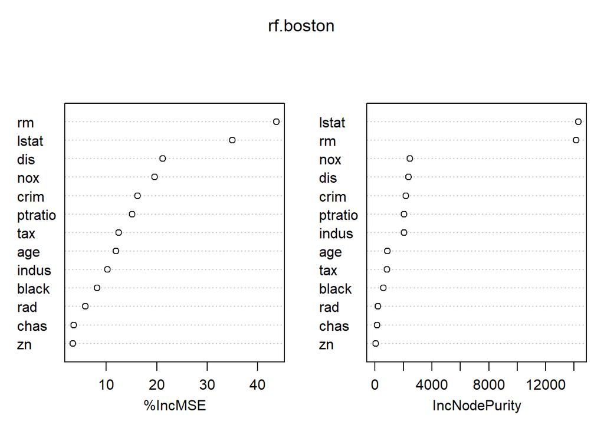

```r
varImpPlot (rf.boston )
```

Результаты показывают, что на всех деревьях, рассматриваемых в случайном лесу, уровень богатства населения (lstat) и размер дома (rm) являются двумя наиболее важными переменными.